# Pea cultivation protocol (ver. 1.0.0)

Keach Murakami

keach.murakami@gmail.com

2018-08-09

# 1 Abstract

Pea (*Pisum sativum* L., cv. Greenfeast) cultivation protocol for ANU works. This protocol is based on [Chow & Anderson, 1987](https://doi.org/10.1071/PP9870001) and [Zhu et al., 2016](https://doi.org/10.1071/FP16222) with some minor modifications.

# 2 Procedure

## 2.1 Sowing (Day 0)

Germination rate is approximately 85–90%. x1.5 seeds should be sown.

- soak seeds in water for ~ 5 h
- sow seeds into cylinders filled with PAC soil
  - cylinder diameter: ~ 37 mm
  - cylinder height: ~ 70 mm
- arrange cylinders in round-hole plug-tray (8 x 5 holes)
- place plug-trays in a growth cabinet
  - temp: 20C
  - RH: 60%
  - PPFD: 360 umol m-2 s-1 (photoperiod: 16 h)
  - CO2: ambient
- water until germination

## 2.2 Transplant (~ Day 6)

Transplant seedlings to pots. The shoot length is ~ 5 mm.

- place papers on the bottom of pots to supress soil runoff
- fill plastic pots (diameter: 150 mm) with PAC soil to depth A (see illustration at the end of this document)
- put ~ 10 grains of slow release fertiliser (Osmocote; Scotts Australia Pty. Ltd.)
- place and bury four cylinders per pot
- supply nutrition twice per week
  - 1 spoon of soluble nutrition (Aquasol for all plant types; Yates, a division of DuluxGroup Pty. Ltd.) in 4.5 L water for ~ 30 pots

## 2.3 Start treatment/measurement (Day 18)

A **third** leaf is usually fully expanded and is suitable for the measurements. You may find an emerging **fifth** leaf.

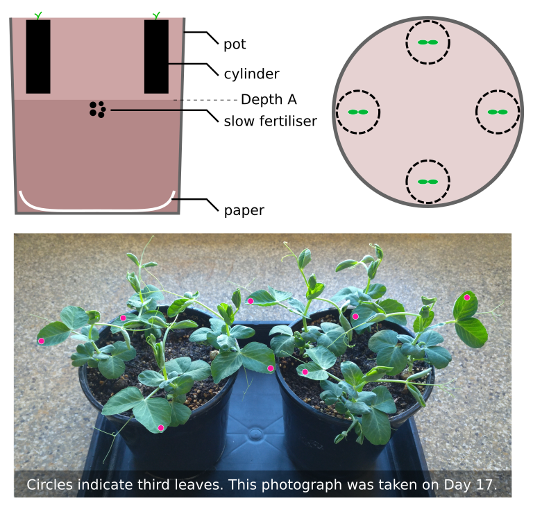

# 3 Reference

- Chow Wah Soon, Anderson Jan M. (1987a) Photosynthetic responses of *Pisum sativum* to an increase in irradiance during growth. I. Photosynthetic activities. Australian Journal of Plant Physiology 14, 1–8.
- Zhu Hui, Zeng Ling-Da, Yi Xiao-Ping, Peng Chang-Lian, Zhang Wang-Feng, Chow Wah Soon (2016) The half-life of the cytochrome *bf* complex in leaves of pea plants after transfer from moderately-high growth light to low light. Functional Plant Biology 44, 351-357.

# 4 Change log

- 2018-08-09: version 1.0.0
  - initial commit